# Question 2

# Introduction

In the following, CRISP-DM process will be applied for a finding an insight about the charactistics of visitors of StackOverflow based on their behaviours.

# Step 1 Business Understanding

The business question defined is:

## What kind of people would like to keep studying new techologies?

Check out current python version

```python
import sys
print(sys.version)
```

```
3.6.3 | packaged by conda-forge | (default, Dec  9 2017, 04:28:46)
[GCC 4.8.2 20140120 (Red Hat 4.8.2-15)]
```

# Step 2 Data Understanding

Import libraries

```python
import numpy as np
import pandas as pd
import matplotlib.pyplot as plt
import seaborn as sns
import proj1_func_library as my_lib
from sklearn.cluster import KMeans
from sklearn.preprocessing import scale
%matplotlib inline
```

Read the datasets

```python
df = pd.read_csv('developer_survey_2020/survey_results_public.csv')
schema = pd.read_csv('developer_survey_2020/survey_results_schema.csv')

df.shape, schema.shape
```

```
((64461, 61), (61, 2))
```

```python
df.describe()
```

|  | Respondent | Age | CompTotal | ConvertedComp | WorkWeekHrs |
| --- | --- | --- | --- | --- | --- |
| count | 64461.000000 | 45446.000000 | 3.482600e+04 | 3.475600e+04 | 41151.000000 |
| mean | 32554.079738 | 30.834111 | 3.190464e+242 | 1.037561e+05 | 40.782174 |
| std | 18967.442360 | 9.585392 | inf | 2.268853e+05 | 17.816383 |
| min | 1.000000 | 1.000000 | 0.000000e+00 | 0.000000e+00 | 1.000000 |
| 25% | 16116.000000 | 24.000000 | 2.000000e+04 | 2.464800e+04 | 40.000000 |
| 50% | 32231.000000 | 29.000000 | 6.300000e+04 | 5.404900e+04 | 40.000000 |
| 75% | 49142.000000 | 35.000000 | 1.250000e+05 | 9.500000e+04 | 44.000000 |
| max | 65639.000000 | 279.000000 | 1.111111e+247 | 2.000000e+06 | 475.000000 |

To review some data of survey data

```python
pd.set_option("display.max_columns", None)

df.head(3)
```

|  | Respondent | MainBranch | Hobbyist | Age | Age1stCode | CompFreq | CompTotal | ConvertedComp | Country | CurrencyDesc | CurrencySymbol | DatabaseDesireNextYear | DatabaseWorkedWith | DevType | EdLevel | Employment | Ethnicity | Gender | JobFactors | JobSat | JobSeek | LanguageDesireNextYear | LanguageWorkedWith | MiscTechDesireNextYear | MiscTechWorkedWith | NEWCollabToolsDesireNextYear | NEWCollabToolsWorkedWith | NEWDevOps | NEWDevOpsImpt | … |
| --- | --- | --- | --- | --- | --- | --- | --- | --- | --- | --- | --- | --- | --- | --- | --- | --- | --- | --- | --- | --- | --- | --- | --- | --- | --- | --- | --- | --- | --- | --- |
| 0 | 1 | I am a developer by profession | Yes | NaN | 13 | Monthly | NaN | NaN | Germany | European Euro | EUR | Microsoft SQL Server | Elasticsearch;Microsoft SQL Server;Oracle | Developer, desktop or enterprise applications;... | Master’s degree (M.A., M.S., M.Eng., MBA, etc.) | Independent contractor, freelancer, or self-em... | White or of European descent | Man | Languages, frameworks, and other technologies ... | Slightly satisfied | I am not interested in new job opportunities | C#;HTML/CSS;JavaScript | C#;HTML/CSS;JavaScript | .NET Core;Xamarin | .NET;.NET Core | Microsoft Teams;Microsoft Azure;Trello | Confluence;Jira;Slack;Microsoft Azure;Trello | No | Somewhat important | … |
| 1 | 2 | I am a developer by profession | No | NaN | 19 | NaN | NaN | NaN | United Kingdom | Pound sterling | GBP | NaN | NaN | Developer, full-stack;Developer, mobile | Bachelor’s degree (B.A., B.S., B.Eng., etc.) | Employed full-time | NaN | NaN | NaN | Very dissatisfied | I am not interested in new job opportunities | Python;Swift | JavaScript;Swift | React Native;TensorFlow;Unity 3D | React Native | Github;Slack | Confluence;Jira;Github;Gitlab;Slack | NaN | NaN | … |
| 2 | 3 | I code primarily as a hobby | Yes | NaN | 15 | NaN | NaN | NaN | Russian Federation | NaN | NaN | NaN | NaN | NaN | NaN | NaN | NaN | NaN | NaN | NaN | NaN | Objective-C;Python;Swift | Objective-C;Python;Swift | NaN | NaN | NaN | NaN | NaN | NaN | … |

To review the null value population

```python
df.isnull().mean().sort_values()
```

```
Respondent                      0.000000
Hobbyist                        0.000698
MainBranch                      0.004638
Country                         0.006035
Employment                      0.009417
NEWSOSites                      0.095965
Age1stCode                      0.101782
YearsCode                       0.105133
EdLevel                         0.109058
LanguageWorkedWith              0.109880
NEWOtherComms                   0.112564
SOVisitFreq                     0.116210
SOAccount                       0.118769
SOComm                          0.123873
OpSys                           0.127721
NEWLearn                        0.128838
NEWStuck                        0.147035
NEWPurpleLink                   0.149827
LanguageDesireNextYear          0.160531
PlatformWorkedWith              0.164720
NEWCollabToolsWorkedWith        0.179612
WelcomeChange                   0.182715
SurveyEase                      0.196382
JobSeek                         0.197546
SurveyLength                    0.197949
UndergradMajor                  0.208902
NEWOffTopic                     0.211865
PlatformDesireNextYear          0.214952
Gender                          0.215696
DatabaseWorkedWith              0.231520
                                  ...
JobFactors                      0.234436
Trans                           0.234498
NEWEdImpt                       0.248150
NEWCollabToolsDesireNextYear    0.266425
SOPartFreq                      0.274104
YearsCodePro                    0.280976
Ethnicity                       0.287197
CurrencyDesc                    0.294581
CurrencySymbol                  0.294581
Age                             0.294985
JobSat                          0.298894
OrgSize                         0.312235
DatabaseDesireNextYear          0.316331
Sexuality                       0.317541
NEWOvertime                     0.329346
NEWDevOps                       0.337801
NEWOnboardGood                  0.338778
MiscTechDesireNextYear          0.342564
NEWJobHunt                      0.344006
WebframeWorkedWith              0.344115
NEWDevOpsImpt                   0.352601
WorkWeekHrs                     0.361614
NEWJobHuntResearch              0.363615
MiscTechWorkedWith              0.374599
CompFreq                        0.378399
WebframeDesireNextYear          0.379097
PurchaseWhat                    0.389336
NEWPurchaseResearch             0.421030
CompTotal                       0.459735
ConvertedComp                   0.460821
Length: 61, dtype: float64
```

To review some data of schema data

```python
schema.head()
```

|  | Column | QuestionText |
| --- | --- | --- |
| 0 | Respondent | Randomized respondent ID number (not in order ... |
| 1 | MainBranch | Which of the following options best describes ... |
| 2 | Hobbyist | Do you code as a hobby? |
| 3 | Age | What is your age (in years)? If you prefer not... |
| 4 | Age1stCode | At what age did you write your first line of c... |

## Exploratory data analysis (EDA) with single variables

### To see the definitions of some columns of interest

```python
my_lib.print_var_desc(schema, "MainBranch")
my_lib.print_var_desc(schema, "Hobbyist")
my_lib.print_var_desc(schema, "Age")
my_lib.print_var_desc(schema, "JobSeek")
my_lib.print_var_desc(schema, "NEWOvertime")
my_lib.print_var_desc(schema, "NEWLearn")
my_lib.print_var_desc(schema, "LanguageWorkedWith")
```

```
MainBranch  =  Which of the following options best describes you today? Here, by "developer" we mean "someone who writes code."
Hobbyist  =  Do you code as a hobby?
Age  =  What is your age (in years)? If you prefer not to answer, you may leave this question blank.
JobSeek  =  Which of the following best describes your current job-seeking status?
NEWOvertime  =  How often do you work overtime or beyond the formal time expectation of your job?
NEWLearn  =  How frequently do you learn a new language or framework?
LanguageWorkedWith  =  Which programming, scripting, and markup languages have you done extensive development work in over the past year, and which do you want to work in over the next year? (If you both worked with the language and want to continue to do so, please check both boxes in that row.)
```

[output not shown]

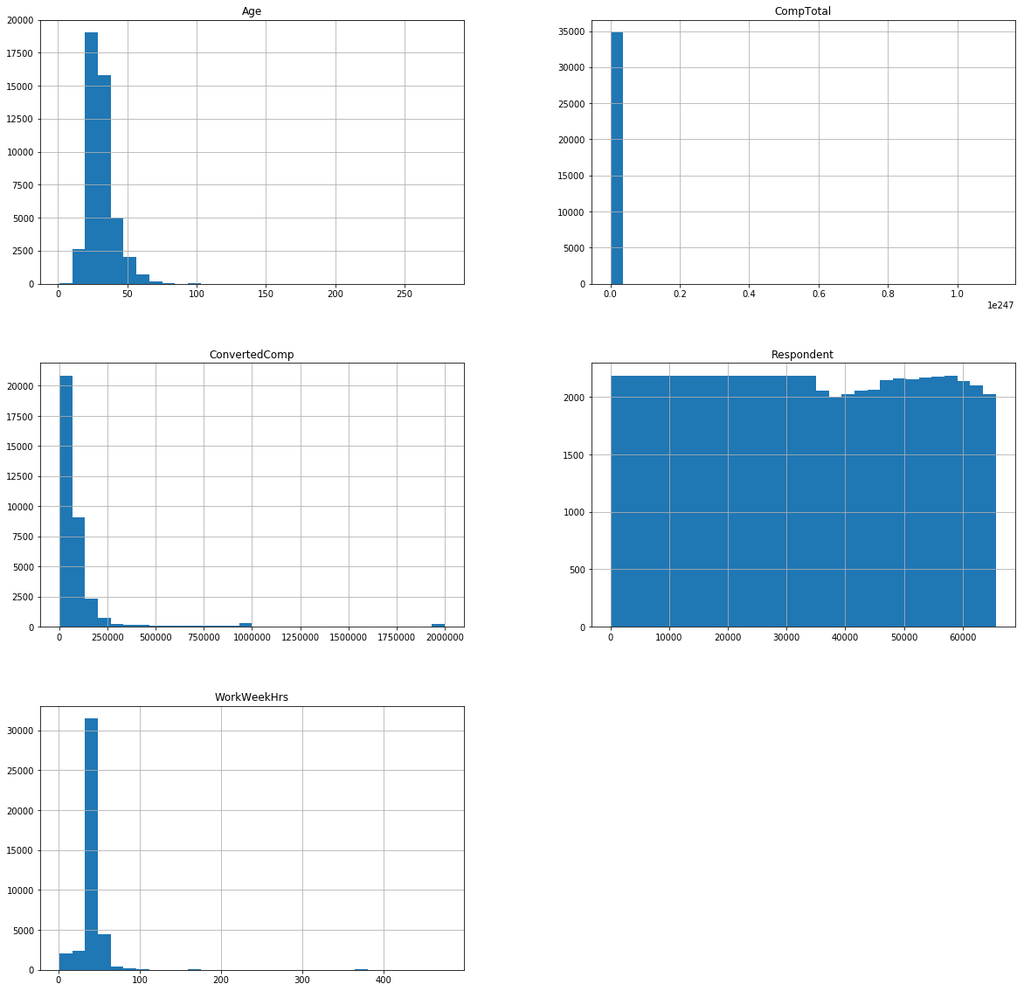

```python
df.hist(bins=30, figsize=(20,20))
```

#### First, the histrogram of Age shows us two things.

1. Most of respondents are around 30 years old.
2. Some instances have 100 years old. Possiblity it contains outliners have to be handled later on.

#### Fourth, we can ignore the population of Respondent because it is the identity of people.

#### Fifth, the most population of WorkWeekHrs is around 40. It means most of people work 40 hours per.

```
JobSeek  =  Which of the following best describes your current job-seeking status?
```

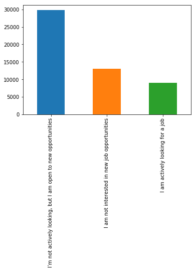

```python
my_lib.print_var_desc_counts_plot(schema, df, "JobSeek")
```

#### Only fewer of 1/3 of people were actively looking for a new job.

```
NEWLearn  =  How frequently do you learn a new language or framework?
```

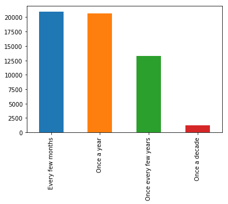

```python
my_lib.print_var_desc_counts_plot(schema, df, "NEWLearn")
```

#### The number of respondents who learn new languages every few months and once a year is totally 40,000. It is over 2/3 of respondents.

#### The rest of 1/4 respondents only learn new language once every few years or a decade.

#### This observation shows that most of respondents keep learning new language or framework frequently.

```
Hobbyist  =  Do you code as a hobby?
```

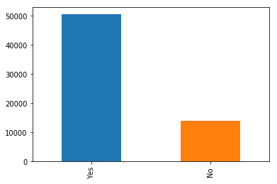

```python
my_lib.print_var_desc_counts_plot(schema, df, "Hobbyist")
```

# Step 3 Data Preparation

After the step of data understanding, Involved variables: Age, JobSeek, NEWLearn, Hobbyist

```python
x_processing = df[["Age", "JobSeek", "NEWLearn", "Hobbyist"]]
x_processing.head()
```

|  | Age | JobSeek | NEWLearn | Hobbyist |
| --- | --- | --- | --- | --- |
| 0 | nan | I am not interested in new job opportunities | Once a year | Yes |
| 1 | nan | I am not interested in new job opportunities | Once a year | No |
| 2 | nan | NaN | Once a decade | Yes |
| 3 | 25.00 | I’m not actively looking, but I am open to new... | Once a year | Yes |
| 4 | 31.00 | NaN | Once a year | Yes |

```python
x_processing.isnull().mean().sort_values()
```

```
Hobbyist   0.00
NEWLearn   0.13
JobSeek    0.20
Age        0.29
dtype: float64
```

## Handle missing values

```python
print('Number of rows (Before dropping): ', x_processing.shape[0])
```

```
Number of rows (Before dropping):  64461
```

##### Drop all rows with null values

```python
x_processing = x_processing.dropna()
print('Number of rows (Before dropping): ', x_processing.shape[0])
```

```
Number of rows (Before dropping):  41538
```

## Handle categorical values

Seems these categorical variables are all rankable. They can all be converted to to ordinal variables.

#### JobSeek

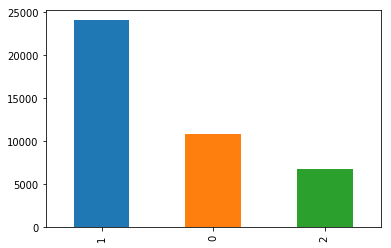

```python
mapping = {
        "I am not interested in new job opportunities":0,
        "I’m not actively looking, but I am open to new opportunities":1,
        "I am actively looking for a job":2
}

my_lib.conv_cat_to_ord(x_processing, 'JobSeek', mapping, True)
```

#### NEWLearn

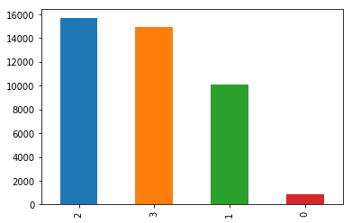

```python
mapping = {
        "Once a decade":0,
        "Once every few years":1,
        "Once a year":2,
        "Every few months":3
}

my_lib.conv_cat_to_ord(x_processing, 'NEWLearn', mapping, True)
```

#### Hobbyist

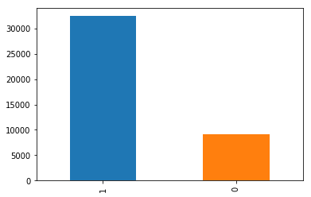

```python
my_lib.conv_cat_to_ord(x_processing, 'Hobbyist', {'Yes':1, 'No':0}, True)
```

## Remove outliers

During the phase of data understanding, we found that the maximum value of age is 279. Obsviously it contains outliers.

```python
# 5 number summary for Age
pd.options.display.float_format = "{:.2f}".format
x_processing["Age"].describe()
```

```
count   41538.00
mean       30.85
std         9.08
min         1.00
25%        25.00
50%        29.00
75%        35.00
max       279.00
Name: Age, dtype: float64
```

Again, the maximum age is 279 years old, obviously this value is outlier.

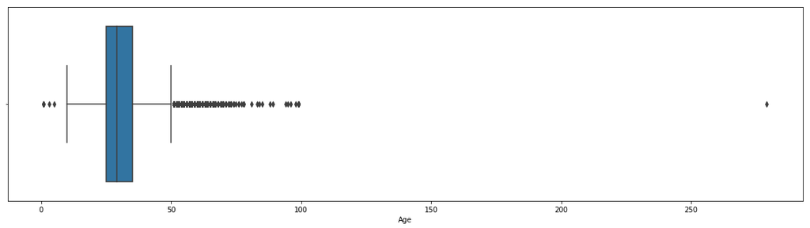

```python
plt.figure(figsize=(20,5))
sns.boxplot(x=x_processing['Age'])
```

According to the boxplot, there are many dots above 50 years old. The dots are all outliers.

Let's remove all instances with age larger than 60 years old.

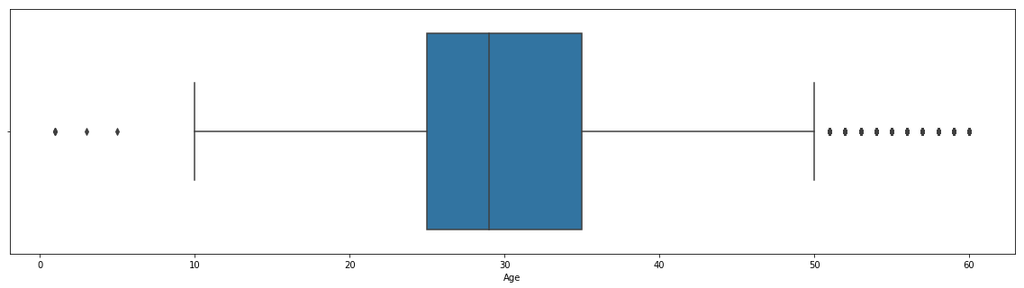

```python
# Remove all instances with age larger than 60 years old
x_processing = x_processing[x_processing['Age'] <= 60]

# Show the boxplot again
plt.figure(figsize=(20,5))
sns.boxplot(x=x_processing['Age'])
```

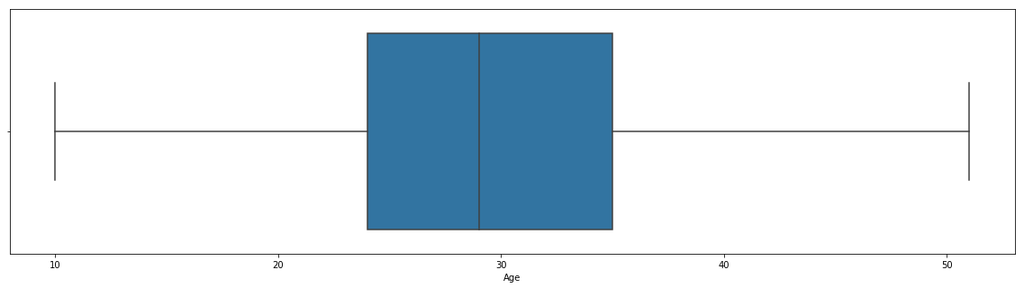

```python
x_processing = x_processing[x_processing['Age'] <= 51]
x_processing = x_processing[x_processing['Age'] >= 10]

# Show the boxplot again
plt.figure(figsize=(20,5))
sns.boxplot(x=x_processing['Age'])
```

Seems no outliers now.

```python
x_processing.head()
```

|  | Age | JobSeek | NEWLearn | Hobbyist | JobSeek_ord | NEWLearn_ord | Hobbyist_ord |
| --- | --- | --- | --- | --- | --- | --- | --- |
| 3 | 25.00 | I’m not actively looking, but I am open to new... | Once a year | Yes | 1 | 2 | 1 |
| 7 | 36.00 | I’m not actively looking, but I am open to new... | Once a year | Yes | 1 | 2 | 1 |
| 8 | 30.00 | I’m not actively looking, but I am open to new... | Once a year | No | 1 | 2 | 0 |
| 9 | 22.00 | I’m not actively looking, but I am open to new... | Every few months | Yes | 1 | 3 | 1 |
| 10 | 23.00 | I am actively looking for a job | Every few months | Yes | 2 | 3 | 1 |

# Step 4 Modeling

In this section, we are going to use different graph and descriptive statistics to find patterns.

## 4.1 NEWLearn VS JobSeek

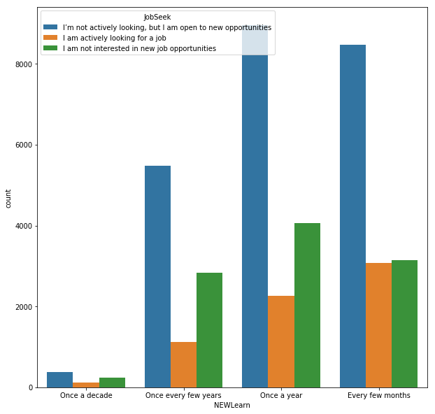

```python
plt.subplots(figsize=[10,10])
sns.countplot(
    x='NEWLearn',
    hue='JobSeek',
    data=x_processing,
    order = ["Once a decade","Once every few years","Once a year","Every few months"] )
```

#### First, there are four groups of frequency of learning new programming languages, they are:

1. Once a decade
2. Once every few years,
3. Once a year,
4. Every few months.

In first three groups, the rate of number of people of job seeking status are the same, even the total numbers of people are different. However, in the last group "Every few months", the number of people who were actively looking for new job is higher. It proves that the people who looking for new job, are willing to learn frequently.

## 4.2 NEWLearn VS Age

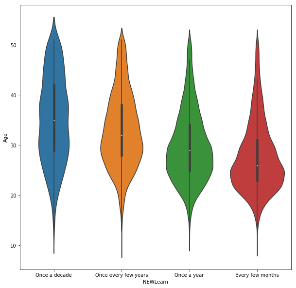

```python
# Violin plot
fig, ax = plt.subplots(figsize=(10,10))
ax = sns.violinplot(
    y="Age",
    x='NEWLearn',
    data=x_processing,
    order = ["Once a decade","Once every few years","Once a year","Every few months"] )
```

#### For the people do not frequently learn new programming language, they are generally order. And people frequently learn new programming language, like every few months, they are younger.

## 4.3 NEWLearn VS Hobbyist

```python
df_NEWLearn_Hobbyist = x_processing.groupby('NEWLearn')["Hobbyist_ord"].mean().sort_values().to_frame()
df_NEWLearn_Hobbyist
```

| NEWLearn | Hobbyist_ord |
| --- | --- |
| Once a decade | 0.59 |
| Once every few years | 0.69 |
| Once a year | 0.79 |
| Every few months | 0.85 |

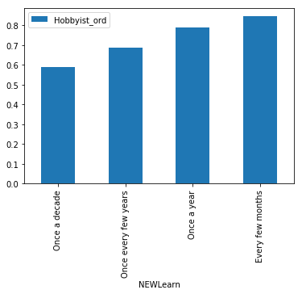

```python
df_NEWLearn_Hobbyist.plot(kind='bar')
```

#### For the people do not frequently learn new programming language, they do not code as hobby so much. And people frequently learn new programming language, like every few months, most of them code as hobby.

# Step 5 Evaluation

### Finally the three diagrams show us the relations between NEWLearn and JobSeek, Age and Hobbyist.

# Step 6 Deploy (Communication)

After looking at the summary table, we got three findings:

#### 1. From the first diagram "NEWLearn VS JobSeek", we saw that people in the group of "Study new technologies every few months" tend to more willingness to actively look for a job.

#### 2. From the second diagram "NEWLearn VS Age", we saw that the people with higher frequency of studying new technologies, they are younger.

#### 3. From the third diagram "NEWLearn VS Hobbyist", we found the positive relation between the frequency of studying new technologies and if the person is hobbyist. When people with higher chance of being hobbyist of programming, their frequency of studying new technologies is higher.